# Estatística Espacial

#### Grupo

- Americo Freitas
- André Martins
- Antonio Junior

#### Professor

- Jony Arrais Pinto Junior

#### Descrição

- Trabalho 2

Dados – Localizações das ocorrências de crimes na cidade de Houston.

Análise – Faça uma análise descritiva/exploratória (apresentação do espaço, do fenômeno de interesse, além de investigar os efeitos de 1a e 2a ordem) das localizações das ocorrências dos crimes de acordo com seus tipos (variável offense). Ao realizar a análise discutam a estimação da função de intensidade e diferentes formas de verificar a existência do efeito de segunda ordem. Discutam as possíveis diferenças observadas entre os efeitos estimados (1a e 2a ordem) dos 7 cenários avaliados.

### Carregando as bibliotecas necessárias para a análise do modelo

### Lendo o shapefile com os bairros de Houston no formato Lat e Long

```r
houston_shp = readOGR("Houston_City_Limit/Houston_City_Limit.shp")
houston=houston_shp
#houston=spTransform(houston_shp, CRS("+proj=longlat +datum=WGS84"))
```

### Carregando a Base Houston (Ocorrencias), e as bases auxiliares separadas por delito.

Bases Auxilares:

- Robbery, Aggravated Assault, Auto Theft, Burglary, Rape, Murder, Hours

```r
#class(houston)

houston_limit<-read.csv2("Base Houston.csv", sep = ",", dec = "." )
houston_limit
```

[output not shown]

[output cut: 11230 more lines]

```r
#------------variavies por delito------------------------------------

hrobbery<-read.csv2("robbery.csv",sep = ";", dec = ".")
hagg<- read.csv2("aggravated assault.csv", dec = ".")
hauto<- read.csv2("auto theft.csv", dec = ".")
hburglary<- read.csv2("burglary.csv", dec = ".")
hrape<- read.csv2("rape.csv", dec = ".")
hmurder<-read.csv2("murder.csv", dec = ".")
write.csv2(houston_limit, "hous.csv")

#ls()
#--------------------------------------------------------------------
```

### Análise do mapa

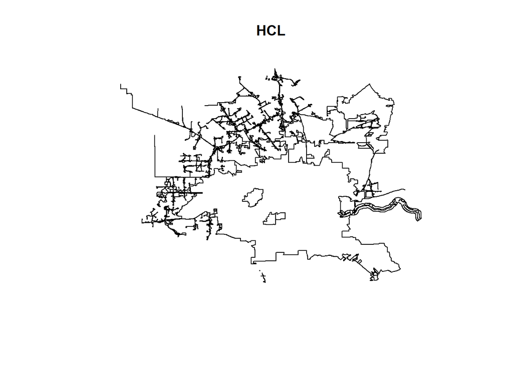

```r
#Definindo o shapefile como uma janela onde os pontos serao plotados
HCL <- as.owin(houston)
#Plotando o shapefile
plot(HCL)
```

```r
#Criando o padrao de pontos a ser plotado
Houston_ppp = ppp(houston_limit$lon, houston_limit$lat,window=HCL )
#---------------criando pontos por delitos-------------------------------
hagg_ppp = ppp(hagg$lon, hagg$lat,window=HCL )
hrobbery_ppp = ppp(hrobbery$lon, hrobbery$lat,window=HCL )
hmurder_ppp = ppp(hmurder$lon,hmurder$lat,window=HCL )
hauto_ppp = ppp(hauto$lon, hauto$lat,window=HCL )
hrape_ppp = ppp(hrape$lon, hrape$lat,window=HCL )
hburglary_ppp = ppp(hburglary$lon, hburglary$lat,window=HCL )
#--------------------------------------------------------------------
```

### Ocorrências de crimes em Houston

Ao observar o mapa, concluímos que existem áreas com maior concentração de ocorrências, sugerindo que os eventos ocorram mais ao centro.

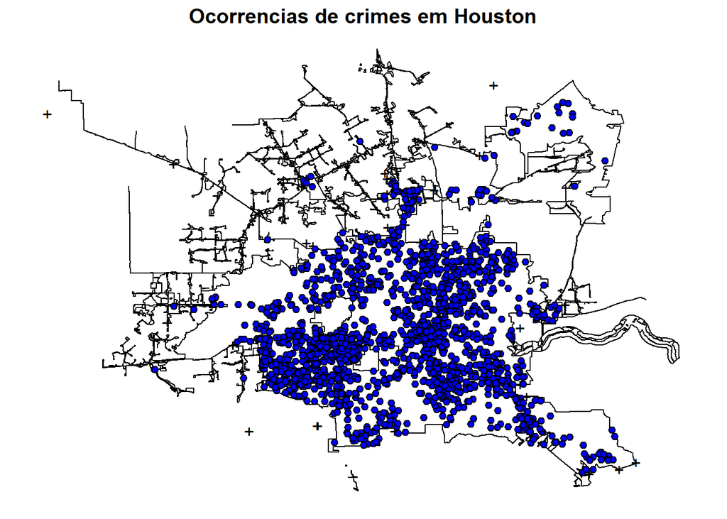

```r
##ppp - criar um objeto com classe ppp representando o padrao de pontos
#Argumentos:
#x - longitude
#y - latitude
#window - um objeto owin.

#Plotando as localizacoes dos delitos
par(mar=c(0.5,0.5,1.5,0.5))

plot(Houston_ppp, pch=21, cex=0.9, bg="blue", main="Ocorrencias de crimes em Houston")
```

### Efeitos de primeira Ordem

#### Análise geral

Ao aplicar o raio dos estimadores com pesos distintos reparamos que para o maior raio (0,03) utilizando o kernel Quártico, temos uma maior suavidade visual nas áreas com menos ocorrências próximas as áreas de maior ocorrência, o que intensifica o alerta visual fornecido pelo mapa. Para o raio menor (0,01) no kernel Normal (gaussiano), conseguimos identificar bem as areas com buracos de ocorrência dos eventos. Para alertar uma situação de perigo, eu avalio o de maior raio (0,03) Quártico como mais adequado.

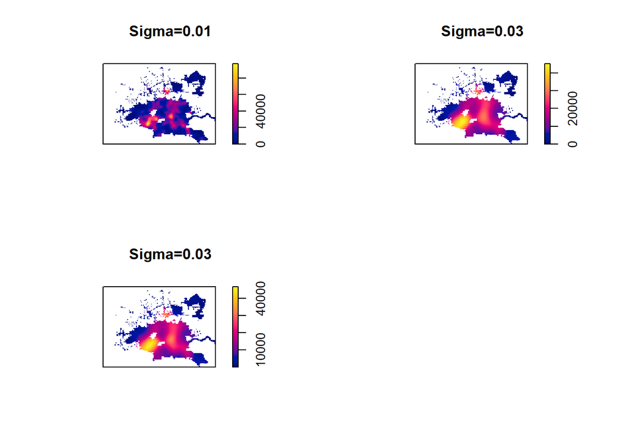

```r
#------------------PRIMEIRA ORDEM-------------------------------------------------------------------
#PLOTANDO GRAFICO EM  EFEITOS EM PRIMEIRA ORDEM
Houston.g = density.ppp(x = Houston_ppp, sigma=0.01, kernel="gaussian")
Houston.q = density.ppp(x = Houston_ppp, sigma=0.01, kernel="quartic")
#Plotando os dados e as funcoes intensidades estimadas pelas diversas funcoes kernel
par(mfrow=c(2,2))

plot(density.ppp(Houston_ppp, sigma=0.01, kernel="gaussian"), main="Sigma=0.01", cex.main=0.5)#gaussian
plot(density.ppp(Houston_ppp, sigma=0.03, kernel="quartic"), main="Sigma=0.03", cex.main=0.5)#quartic
plot(density.ppp(Houston_ppp, sigma=0.03, kernel="gaussian"), main="Sigma=0.03", cex.main=0.5)#quartic
##density.ppp - calcula a funcao de intensidade de acordo com o kernel escolhido
#Argumentos:
#x - objeto da classe ppp
#sigma - é o valor do raio (tau na expressao dos slides)
#kernel - o kernel que deseja-se usar
```

#### Análise por delito

Ao analisar cada delito separadamente, identificamos que as regiões de predominancia de ocorrências são razoavelmente comuns idependente do delito.

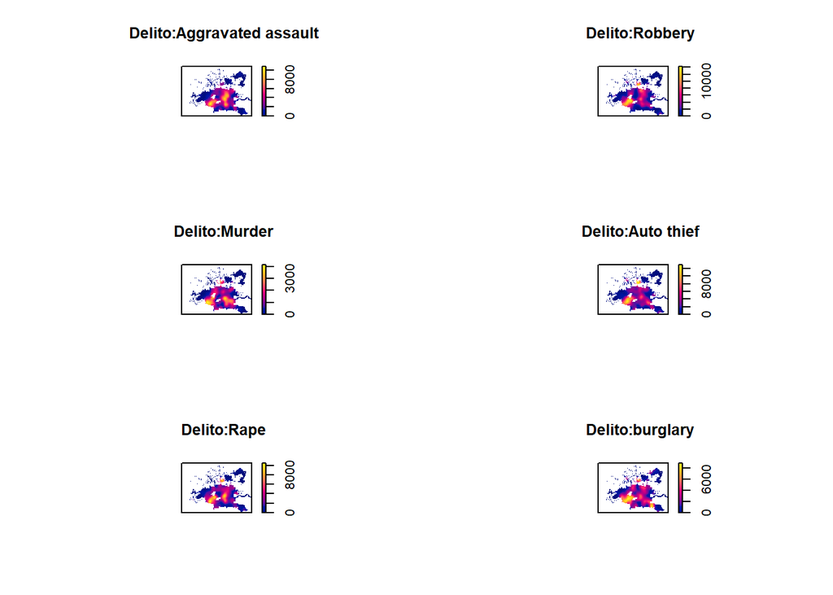

```r
#----------------PLOTANDO GRAFICO EM  EFEITOS EM PRIMEIRA ORDEM POR DELITO

par(mfrow=c(3,2))
plot(density.ppp(hagg_ppp , sigma=0.02, kernel="gaussian"), main="Delito:Aggravated assault", cex.main=0.5)#quartic
plot(density.ppp(hrobbery_ppp , sigma=0.02, kernel="gaussian"), main="Delito:Robbery", cex.main=0.5)#quartic
plot(density.ppp(hmurder_ppp , sigma=0.02, kernel="gaussian"), main="Delito:Murder", cex.main=0.5)#quartic
plot(density.ppp(hauto_ppp , sigma=0.02, kernel="gaussian"), main="Delito:Auto thief", cex.main=0.5)#quartic
plot(density.ppp(hrape_ppp  , sigma=0.02, kernel="gaussian"), main="Delito:Rape", cex.main=0.5)#quartic
plot(density.ppp(hburglary_ppp , sigma=0.02, kernel="gaussian"), main="Delito:burglary", cex.main=0.5)#quartic
```

```r
par(mar=c(0.5,0.5,1.5,0.5))
```

### Análise por crimes

Ao analisar os pontos por validação cruzada, para suavisação do kernel, a largura de banda estimada é de aproximadamente 0.0029.

```r
#--------------------plotando graficos por crimes-------------------------------

#Plotando o grafico com recursos do Google Maps
#Criando o grafico com a densidade e o layout do Google Maps
#HT <- get_map("Houston, Texas", zoom=8,maptype='hybrid')
#plot(HT)
#google = plot(HT) + stat_density2d(aes(x=lat,y=lon, fill = ..level..),alpha = .8, h=.025, n = 400,geom = "polygon", data = houston_limit)
#plot(google)
#google+ scale_fill_gradient(low = "black", high= "red") + facet_wrap(~ offense)

#Funcao que estima o raio por meio de validacao cruzada (custosa computacionalmente)
raio.est = bw.diggle(Houston_ppp)
raio.est
```

```
##       sigma
## 0.002992444
```

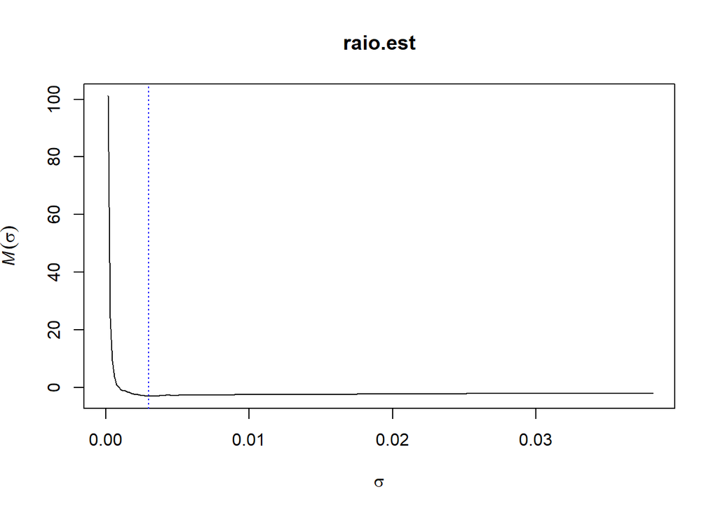

```r
plot(raio.est)
```